# Data Science With an Eye Towards Sustainability Activity A4: Multivariate Visualization II

Ian Lum

# 1 Olin’s Natural Gas Consumption

In this activity, we’ll practice using visualizations to explore relationships between multiple variables. We’ll examine Olin’s natural gas consumption data (July 2012 - November 2022) and resulting bills (January 2017 - November 2022). Here is some information about the data:

- This data only covers Olin’s commercial gas contracts, which supply the natural gas for the Central Heating Plant, Large Projects Building (LPB), Milas Hall, Miller Academic Center, Campus Center, West Hall, and East Hall; the natural gas service for the [five smaller houses on campus](https://franklyspeakingnews.com/2012/11/whats-in-the-olin-houses/) is through residential contracts, and these bills are much smaller and excluded from this data set.
- The monthly consumption is reported separately for each of the buildings. However, the Central Heating Plant supplies heat to the whole campus, except for the LPB. Thus, the natural gas for the other buildings is primarily used for other purposes, like heating potable water (e.g., to drink or shower) and powering gas stoves.
- For each building, the total costs are broken out into two categories: supply and delivery. Delivery is for Olin’s contract with Eversource, the company that delivers natural gas through the pipelines to Olin. It includes a (small) fixed cost each month and then a variable cost that is some rate times the number of therms consumed. Supply is for the actual natural gas consumed. Olin periodically changes its supplier to get the lowest rates possible. This portion of the bill is entirely variable cost (i.e., a monthly rate ($/therm) times the number of therms consumed). The monthly rate does vary over time.
- Olin consumes 275,000-315,000 therms per year and incurs total natural gas costs of $250,000-$300,000 per year.

We’ll start by loading the data:

```r
gas_usage<-read_csv("http://faculty.olin.edu/dshuman/DS/olin_natural_gas_usage.csv",col_type=list(building = readr::col_factor()))
gas_usage$month <- factor(gas_usage$month, levels=month.abb)
```

Here is the monthly natural gas consumption history by building:

|  | building | therms | date | month | year |
| --- | --- | --- | --- | --- | --- |
| 1 | Central Heating Plant | 0 | 2012-07-01 | Jul | 2012 |
| 2 | Central Heating Plant | 0 | 2012-08-01 | Aug | 2012 |
| 3 | Central Heating Plant | 2430 | 2012-09-01 | Sep | 2012 |
| 4 | Central Heating Plant | 8171 | 2012-10-01 | Oct | 2012 |
| 5 | Central Heating Plant | 15008 | 2012-11-01 | Nov | 2012 |
| 6 | Central Heating Plant | 18015 | 2012-12-01 | Dec | 2012 |
| 7 | Central Heating Plant | 23030 | 2013-01-01 | Jan | 2013 |
| 8 | Central Heating Plant | 22352 | 2013-02-01 | Feb | 2013 |
| 9 | Central Heating Plant | 17361 | 2013-03-01 | Mar | 2013 |
| 10 | Central Heating Plant | 3235.96 | 2013-04-01 | Apr | 2013 |

[output cut: 865 more lines]

**Exercise 1.1 (Units of observation)** What does each row correspond to in the data table?

*Solution*. Each row is a building and a month

# 2 Consumption Trends Over Time By Building

Let’s start with a line plot of each building’s monthly natural gas consumption history:

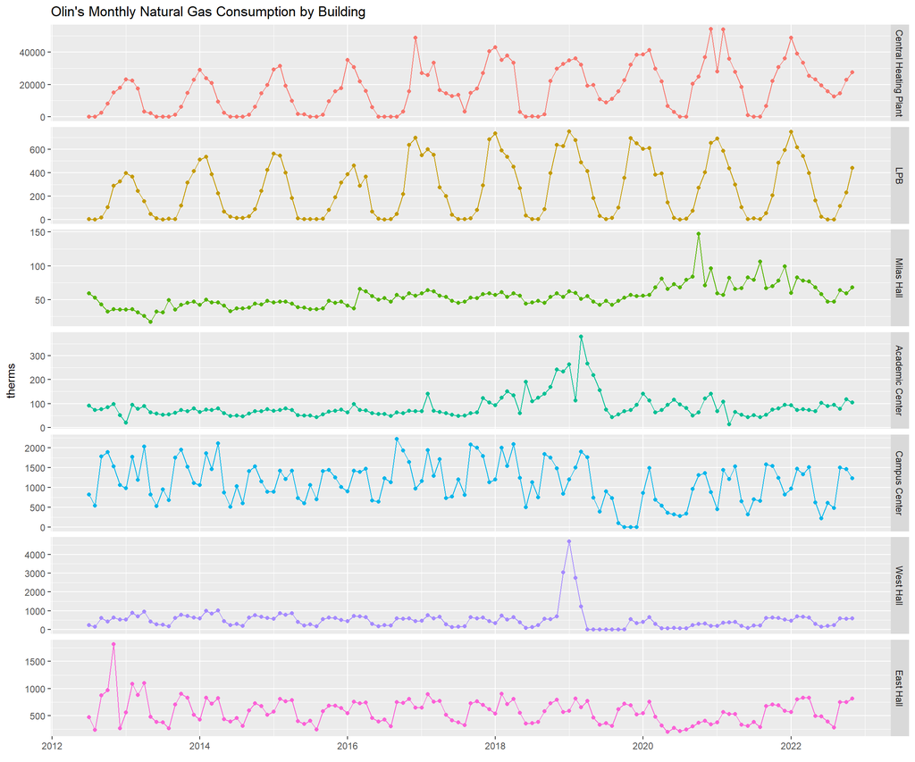

```r
ggplot(gas_usage,aes(x=date,y=therms,color=building))+
  geom_point()+
  geom_line()+
  facet_grid(rows=vars(building),scales="free")+
  theme(legend.position = "none")+
  ggtitle("Olin's Monthly Natural Gas Consumption by Building")+
  labs(x=element_blank())
```

**Exercise 2.1 (Careful interpretation of a graphic)**

1. Examine the code used to generate this plot to make sure you understand each line.
2. Make two observations about the plot.
3. Write down two questions about the patterns you see that you would like to ask Claire Rodgers, Olin’s amazing Associate Director of Sustainability and Building Operations who collects and is familiar with this data.

*Solution*. b1. The periodic consumption of the LPB and central heating corresponds to summer b2. There was a very significant spike in West Hall in the start of 2019 c1. What happened in West Hall in the start of 2019 c2. Why is the campus center’s usage so sporatic?

**Exercise 2.2 (Side-by-side density plots)** In the plot above, the y-axis scales are different for each building. This helps our ability to see the increases and decreases in consumption for each building, but makes it harder to get a relative sense of the scale of consumption across buildings. Make a side-by-side density plot that shows the distributions of monthly natural gas consumptions for each building. Specifically, let your x-axis be the number of therms and there should be one density plot per building that includes all of that building’s monthly natural gas consumptions in the given data. To make it easier to compare, you may want to facet by `building`, as done in the previous plot. What is the main takeaway from this plot?

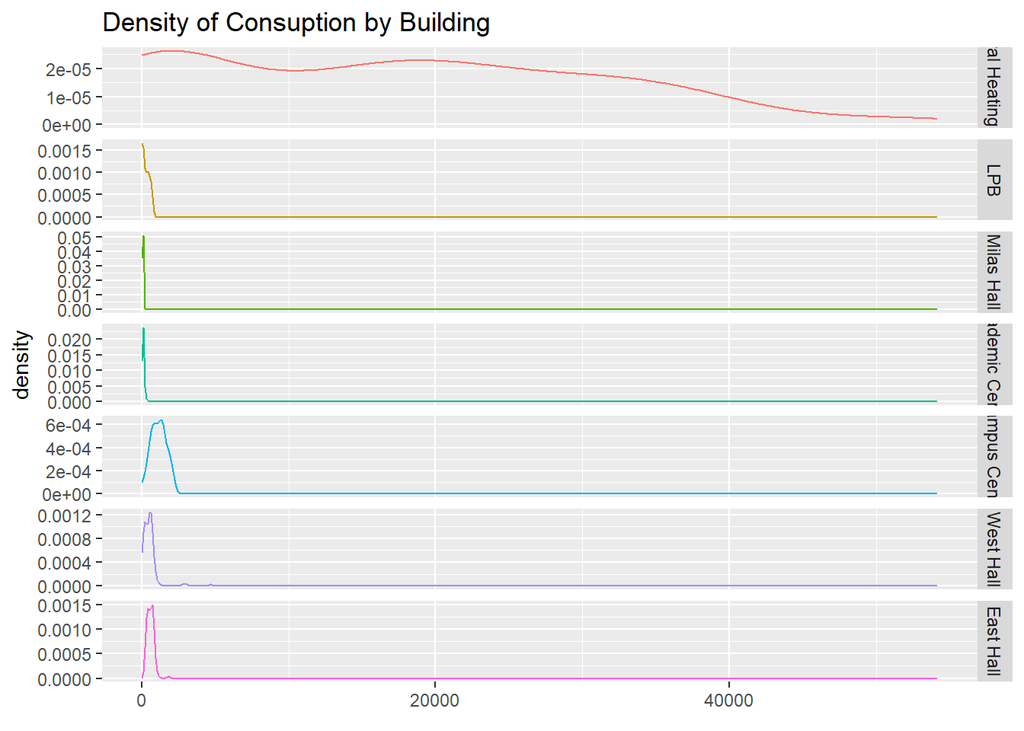

```r
ggplot(gas_usage,aes(x=therms,color=building))+
  geom_density()+
  facet_grid(rows=vars(building),scales="free")+
  theme(legend.position = "none")+
  ggtitle("Density of Consuption by Building")+
  labs(x=element_blank())
```

**Exercise 2.3 (Portion of total consumption by building)** Next, we want to answer the question, “How does the breakdown of natural gas consumption across the buildings change through the course of the year?”

1. Write code to replicate one of the following two plots as closely as possible.
2. Use your plot to answer the question.

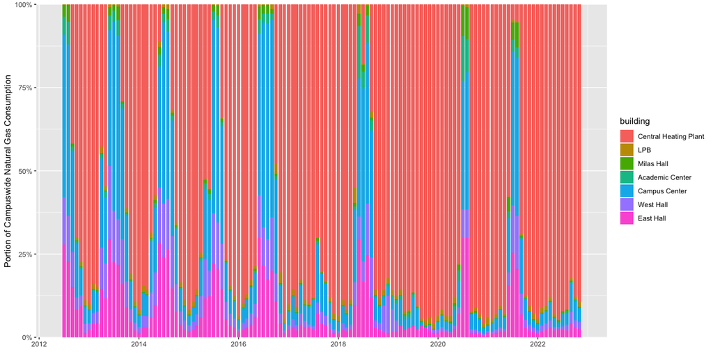

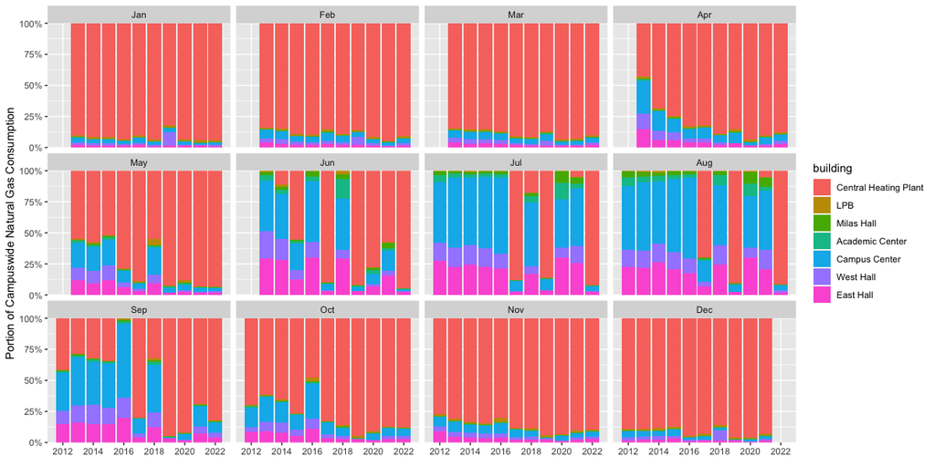

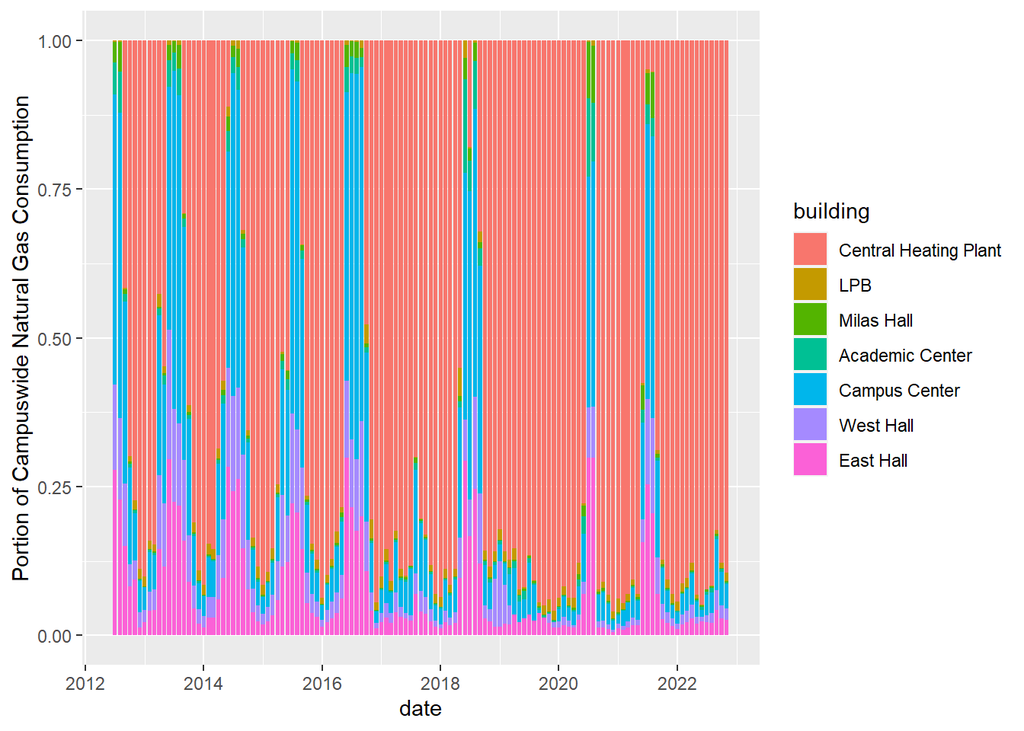

```r
ggplot(gas_usage, aes(x=date,y=therms,fill=building))+
  geom_col(position="fill")+
  labs(y="Portion of Campuswide Natural Gas Consumption")
```

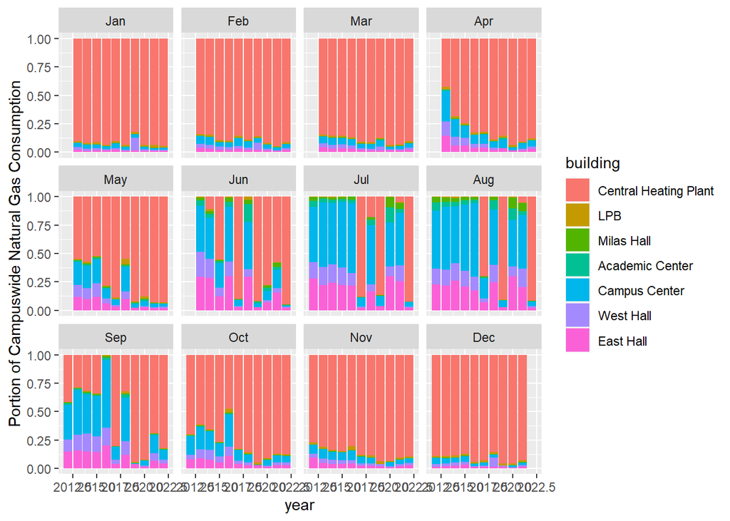

```r
ggplot(gas_usage, aes(x=year,y=therms,fill=building))+
  geom_col(position="fill")+
  facet_wrap(~month)+
  labs(y="Portion of Campuswide Natural Gas Consumption")
```

::: {.solution} Central heating drops or everything else spikes during summer, likely central heating drops. :::

**Exercise 2.4 (Year-over-year trends)** Now we want to answer the question, “For each building, how does the year-over-year natural gas consumption trend look for each month?” For example, in West Hall, how does the October 2017 consumption compare to October 2018, October 2019, etc.?

1. Write code to replicate the following plot as closely as possible.
2. Make two observations about the plot.
3. Write down two follow-up questions about the patterns you see.

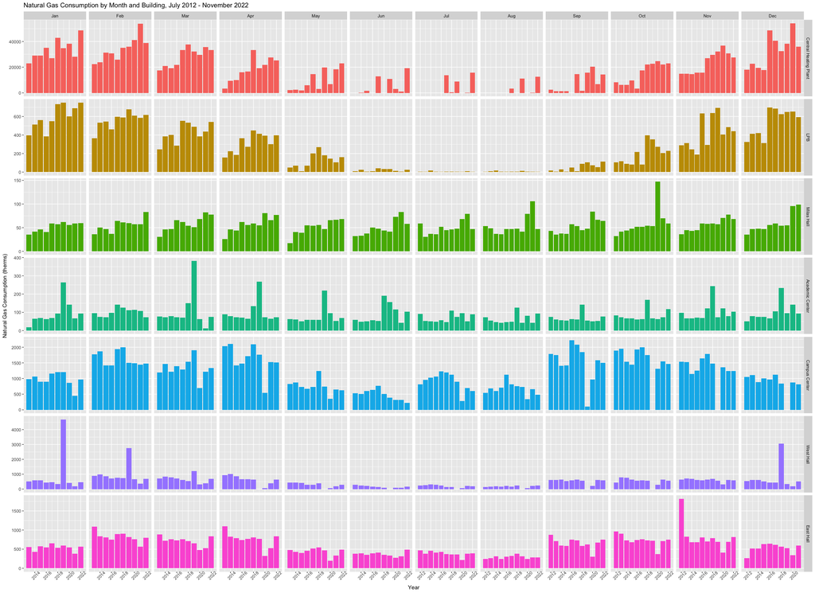

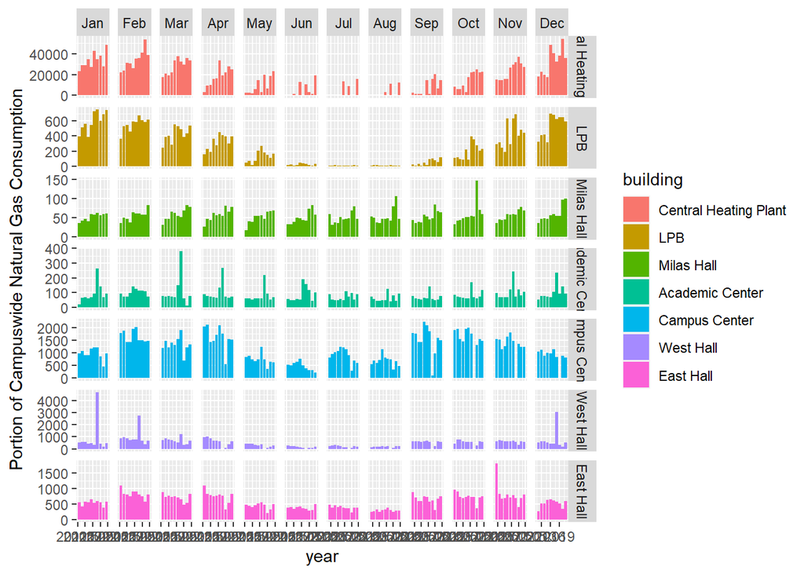

```r
ggplot(gas_usage, aes(x=year,y=therms,fill=building))+
  geom_col()+
  facet_grid(building~month, scales="free")+
  labs(y="Portion of Campuswide Natural Gas Consumption")
```

# 3 Campuswide Consumption Trends Over Time

Next we’ll examine natural gas consumption trends, aggregated across all of the buildings. Let’s load the data and examine it:

```r
gas_usage_totals<-read_csv("http://faculty.olin.edu/dshuman/DS/olin_natural_gas_usage_totals.csv",col_type=list(year=readr::col_factor()))
```

|  | month | year | total_therms |
| --- | --- | --- | --- |
| 1 | Jan | 2013 | 25547 |
| 2 | Jan | 2014 | 31730 |
| 3 | Jan | 2015 | 31871 |
| 4 | Jan | 2016 | 37346 |
| 5 | Jan | 2017 | 29987 |
| 6 | Jan | 2018 | 45839 |
| 7 | Jan | 2019 | 42381 |
| 8 | Jan | 2020 | 40995 |
| 9 | Jan | 2021 | 29907 |
| 10 | Jan | 2022 | 51554 |

[output cut: 115 more lines]

**Exercise 3.1 (New units of observation)** What does each row correspond to in the data table?

*Solution*. Each row is a month and a year

**Exercise 3.2 (Interpretation practice)** Examine the following four plots.

1. Compare Plot A and Plot B. What are their similarities and differences? Are there stories that are easier to takeaway from one or the other?
2. Compare Plot C and Plot D. What are their similarities and differences? Are there stories that are easier to takeaway from one or the other?
3. Compare Plot B and Plot D. What are their similarities and differences? Are there stories that are easier to takeaway from one or the other?
4. If you could use just one of these plots to show both seasonal trends and year-over-year trends, which would you pick?

*Solution*.

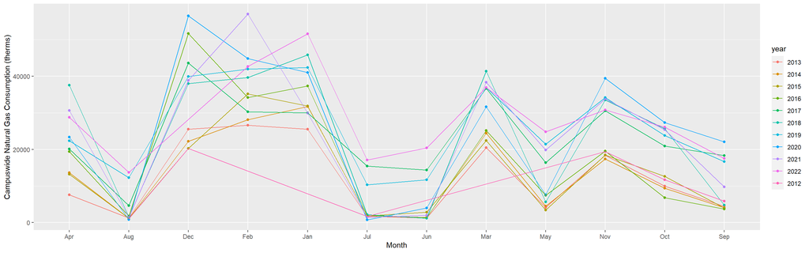

```r
# Plot A
ggplot(gas_usage_totals,aes(x=month,y=total_therms,color=year,group=year))+
  geom_point()+
  geom_line()+
   labs(y="Campuswide Natural Gas Consumption (therms)",x="Month")
```

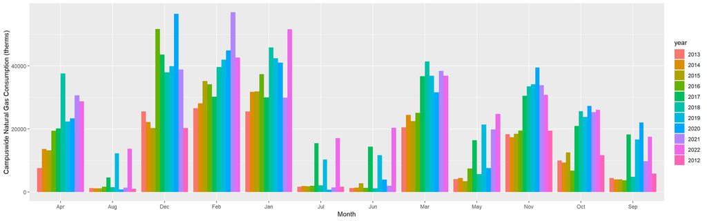

```r
# Plot B
ggplot(gas_usage_totals,aes(x=month,y=total_therms,fill=year))+
  geom_col(position="dodge")+
   labs(y="Campuswide Natural Gas Consumption (therms)",x="Month")
```

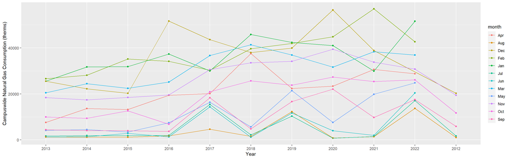

```r
# Plot C
ggplot(gas_usage_totals,aes(x=year,y=total_therms,color=month,group=month))+
  geom_point()+
  geom_line()+
   labs(y="Campuswide Natural Gas Consumption (therms)",x="Year")
```

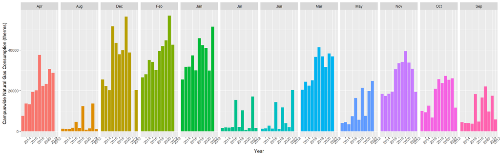

```r
# Plot D
ggplot(gas_usage_totals,aes(x=year,y=total_therms,fill=month))+
  geom_col(position="dodge")+
  facet_grid(~month)+
  scale_x_discrete(breaks=seq(2012,2022,by=2))+
  labs(y="Campuswide Natural Gas Consumption (therms)",x="Year")+
  theme(legend.position = "none",axis.text.x=element_text(angle=45))
```

# 4 Olin’s Natural Gas Cost Trends

Now we’ll examine data on the actual costs associated with the natural gas consumption we’ve explored above. Let’s load two versions of the data. In the first version, the costs are separated out by building:

```r
gas_costs<-read_csv("http://faculty.olin.edu/dshuman/DS/olin_natural_gas_spending.csv",col_type=list(building = readr::col_factor()))
```

|  | building | date | month | year | delivery_cost | supply_cost | therms | total_cost | delivery_cost_per_therm | supply_cost_per_therm | total_cost_per_therm |
| --- | --- | --- | --- | --- | --- | --- | --- | --- | --- | --- | --- |
| 1 | Central Heating Plant | 2017-01-01 | Jan | 2017 | 6913.47 | 19758.32 | 27025 | 26671.79 | 0.256 | 0.731 | 0.987 |
| 2 | Central Heating Plant | 2017-02-01 | Feb | 2017 | 6617.76 | 17784.1 | 25845 | 24401.86 | 0.256 | 0.688 | 0.944 |
| 3 | Central Heating Plant | 2017-03-01 | Mar | 2017 | 8496.26 | 22325.59 | 33341 | 30821.85 | 0.255 | 0.67 | 0.924 |
| 4 | Central Heating Plant | 2017-04-01 | Apr | 2017 | 4295.44 | 11742.3 | 16578 | 16037.74 | 0.259 | 0.708 | 0.967 |
| 5 | Central Heating Plant | 2017-05-01 | May | 2017 | 2517.36 | 10019.51 | 14561 | 12536.87 | 0.173 | 0.688 | 0.861 |
| 6 | Central Heating Plant | 2017-06-01 | Jun | 2017 | 2271.36 | 9041.31 | 12921 | 11312.67 | 0.176 | 0.7 | 0.876 |
| 7 | Central Heating Plant | 2017-07-01 | Jul | 2017 | 2366.88 | 9385.08 | 13639 | 11751.96 | 0.174 | 0.688 | 0.862 |
| 8 | Central Heating Plant | 2017-08-01 | Aug | 2017 | 670.92 | 2234.28 | 3247 | 2905.2 | 0.207 | 0.688 | 0.895 |
| 9 | Central Heating Plant | 2017-09-01 | Sep | 2017 | 2546.29 | 10150.73 | 14703 | 12697.02 | 0.173 | 0.69 | 0.864 |
| 10 | Central Heating Plant | 2017-10-01 | Oct | 2017 | 2976.81 | 11956.53 | 17376 | 14933.34 | 0.171 | 0.688 | 0.859 |

[output cut: 487 more lines]

In the second version, they are aggregated across all buildings:

```r
campus_gas_costs<-read_csv("http://faculty.olin.edu/dshuman/DS/olin_natural_gas_spending_totals.csv")
```

|  | date | month | year | total_delivery_cost | total_supply_cost | total_therms | total_cost | total_delivery_cost_per_therm | total_supply_cost_per_therm | total_cost_per_therm |
| --- | --- | --- | --- | --- | --- | --- | --- | --- | --- | --- |
| 1 | 2017-01-01 | Jan | 2017 | 7986.64 | 21923.87 | 29987 | 29910.51 | 0.266 | 0.731 | 0.997 |
| 2 | 2017-02-01 | Feb | 2017 | 8124.05 | 20968.67 | 30244 | 29092.72 | 0.269 | 0.693 | 0.962 |
| 3 | 2017-03-01 | Mar | 2017 | 9688.37 | 24412.86 | 36678 | 34101.23 | 0.264 | 0.666 | 0.93 |
| 4 | 2017-04-01 | Apr | 2017 | 5490.1 | 14185.78 | 20129 | 19675.88 | 0.273 | 0.705 | 0.977 |
| 5 | 2017-05-01 | May | 2017 | 3118.28 | 11282.87 | 16397 | 14401.15 | 0.19 | 0.688 | 0.878 |
| 6 | 2017-06-01 | Jun | 2017 | 2746.39 | 10035.624 | 14366 | 12782.013 | 0.191 | 0.699 | 0.89 |
| 7 | 2017-07-01 | Jul | 2017 | 2891.65 | 10635.37 | 15456 | 13527.02 | 0.187 | 0.688 | 0.875 |
| 8 | 2017-08-01 | Aug | 2017 | 1117.32 | 3192.83 | 4640 | 4310.15 | 0.241 | 0.688 | 0.929 |
| 9 | 2017-09-01 | Sep | 2017 | 3481.65 | 12628.53 | 18283 | 16110.18 | 0.19 | 0.691 | 0.881 |
| 10 | 2017-10-01 | Oct | 2017 | 3960.28 | 13967.99 | 20923 | 17928.27 | 0.189 | 0.668 | 0.857 |

[output cut: 61 more lines]

**Exercise 4.1 (Units of observation)** What does each row correspond to in the two data tables?

*Solution*.

- gas costs: A building a month and a year
- campus gas costs: A month and a year

**Exercise 4.2 (Optional exercise: Total natural gas cost by building and month)** This exercise is optional. Make a plot identical to the one in Exercise 2.4, except with total cost in dollars on the y-axis instead of consumption in therms. What are you main takeaways?

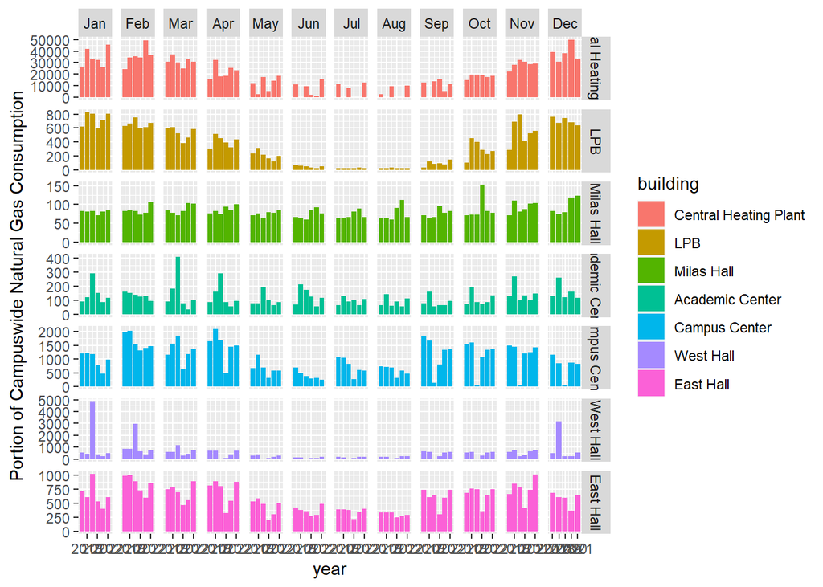

```r
ggplot(gas_costs_rounded, aes(x=year,y=total_cost,fill=building))+
  geom_col()+
  facet_grid(building~month, scales="free")+
  labs(y="Portion of Campuswide Natural Gas Consumption")
```

::: {.solution} Consumption during the winter is very expensive :::

**Exercise 4.3 (Simple line plot practice)** Make two separate plots, each with a single line (with overlaying points): a. Olin’s total monthly cost for natural gas over time (one point per month). b. The average cost per therm over time (one point per month).

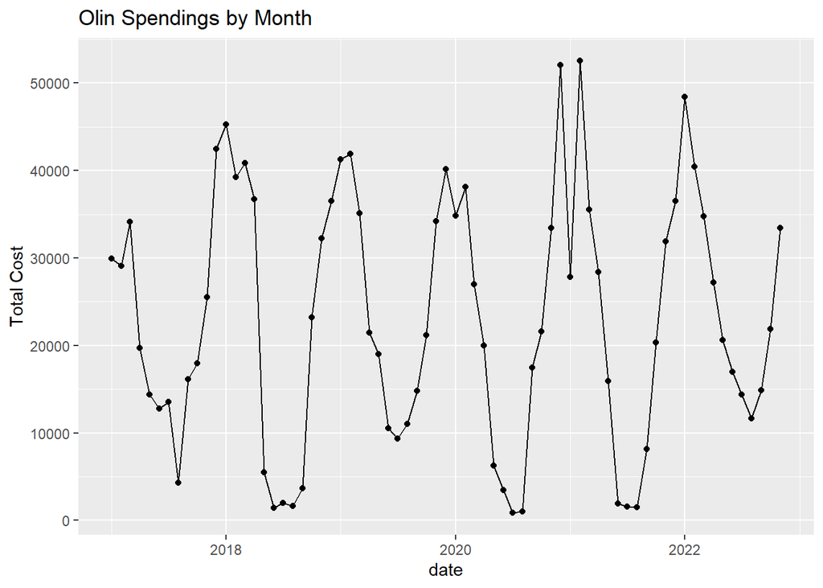

```r
ggplot(campus_gas_costs_rounded, aes(x=date, y=total_cost))+
  geom_point()+geom_line()+
  labs(y="Total Cost", title="Olin Spendings by Month")
```

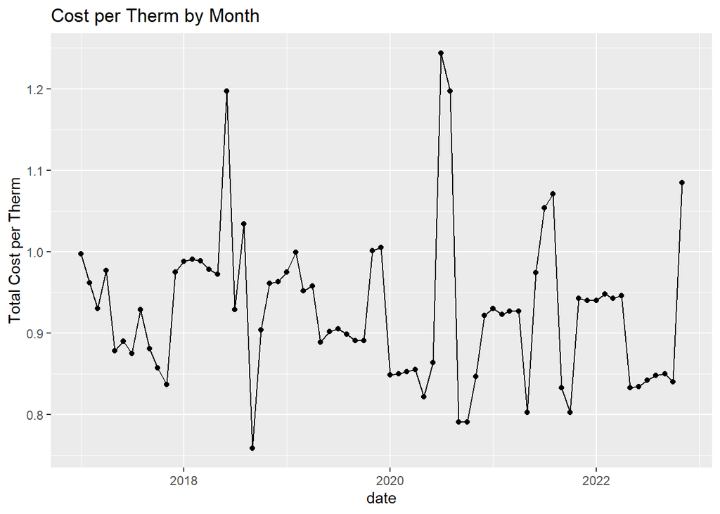

```r
ggplot(campus_gas_costs_rounded, aes(x=date, y=total_cost_per_therm))+
  geom_point()+geom_line()+
  labs(y="Total Cost per Therm", title="Cost per Therm by Month")
```

**Exercise 4.4 (More interpretation practice)** Examine the two graphs below and use them to answer the following questions.

1. Does cost per therm fluctuate more in the summer or winter? Any idea why?
2. Pick a month. Looking over the five years or so of data, what is the rough difference in savings for that month between the year when Olin spent the most on natural gas and the least on natural gas? Is that a meaningful difference?

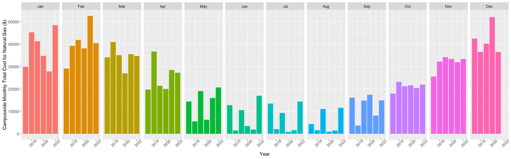

```r
ggplot(campus_gas_costs_rounded,aes(x=year,y=total_cost,fill=month))+
  geom_col(position="dodge")+
  facet_grid(~month)+
  labs(y="Campuswide Monthly Total Cost for Natural Gas ($)",x="Year")+
  theme(legend.position = "none",axis.text.x=element_text(angle=45))
```

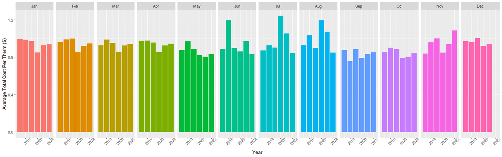

```r
ggplot(campus_gas_costs_rounded,aes(x=year,y=total_cost_per_therm,fill=month))+
  geom_col()+
  facet_grid(~month)+
  labs(y="Average Total Cost Per Therm ($)",x="Year")+
  theme(legend.position = "none",axis.text.x=element_text(angle=45))
```

*Solution*.

1. Seems like a lot more during the summer, there are a couple big spikes July and June
2. Least: August, Most: December, savings: ~$35,000

# 5 Heat Maps to Visualize Multiple Variables

There are multiple ways in `R` to generate *heat maps* to examine multiple variables. We’ll examine a few here.

## 5.1 geom_tile()

We can use the `geom_tile()` layer in the `ggplot2` package to make a heat map, as follows:

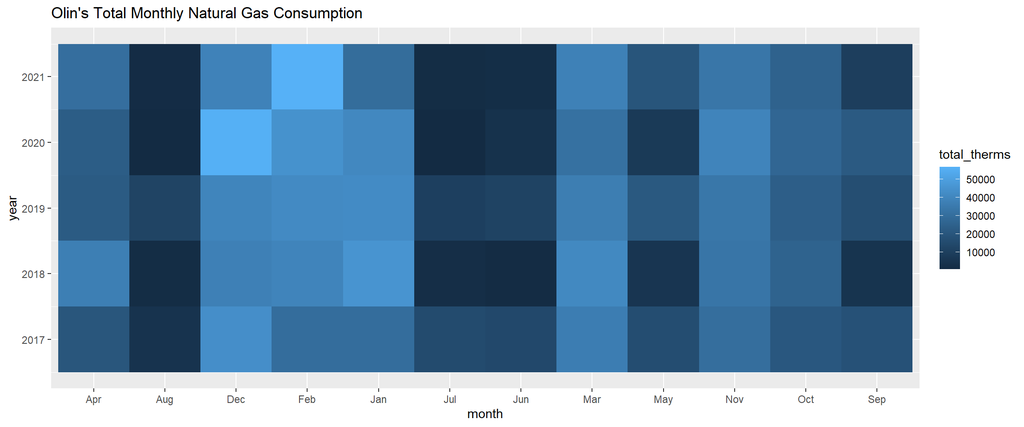

```r
campus_gas_costs2<-filter(campus_gas_costs,year>2012,year<2022)
ggplot(campus_gas_costs2,aes(x=month,y=year,fill=total_therms))+
  geom_tile()+
  ggtitle("Olin's Total Monthly Natural Gas Consumption")
```

And there are many color scheme options via `scale_fill_gradient`, `scale_fill_brewer`, `scale_fill_distiller`, etc.:

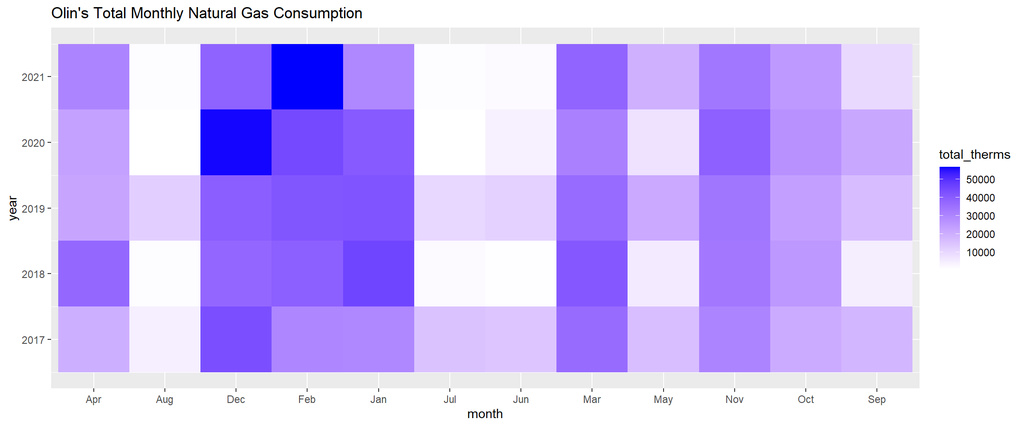

```r
ggplot(campus_gas_costs2,aes(x=month,y=year,fill=total_therms))+
  geom_tile()+
  ggtitle("Olin's Total Monthly Natural Gas Consumption")+
  scale_fill_gradient(low="white", high="blue")
```

## 5.2 heatmap.2

The function `heatmap.2` in the `gplots` package makes similar plots, but the starting table structure should be a data frame instead of the Tidyverse’s tibble and it should already look like the matrix you want to show:

```r
campus_gas_costs3
```

```
## # A tibble: 5 × 13
##    year   Jan   Feb   Mar   Apr   May   Jun   Jul   Aug   Sep   Oct   Nov   Dec
##   <dbl> <dbl> <dbl> <dbl> <dbl> <dbl> <dbl> <dbl> <dbl> <dbl> <dbl> <dbl> <dbl>
## 1  2017 29987 30244 36678 20129 16397 14366 15456  4640 18283 20923 30530 43560
## 2  2018 45839 39610 41359 37562  5679  1214  2176  1555  4810 25654 33531 37935
## 3  2019 42381 41929 36875 22373 21404 11718 10291 12283 16634 23794 34159 39948
## 4  2020 40995 44838 31633 23363  7611  3970   725   820 22041 27299 39442 56493
## 5  2021 29907 56962 38346 30617 19831  1979  1505  1393  9763 25353 33828 38811
```

```r
campus_gas_costs3<-as.data.frame(campus_gas_costs3) # convert from tibble to data frame
row.names(campus_gas_costs3)<-campus_gas_costs3$year
campus_gas_costs3<-campus_gas_costs3[,2:13]
campus_gas_mat <- data.matrix(campus_gas_costs3)
```

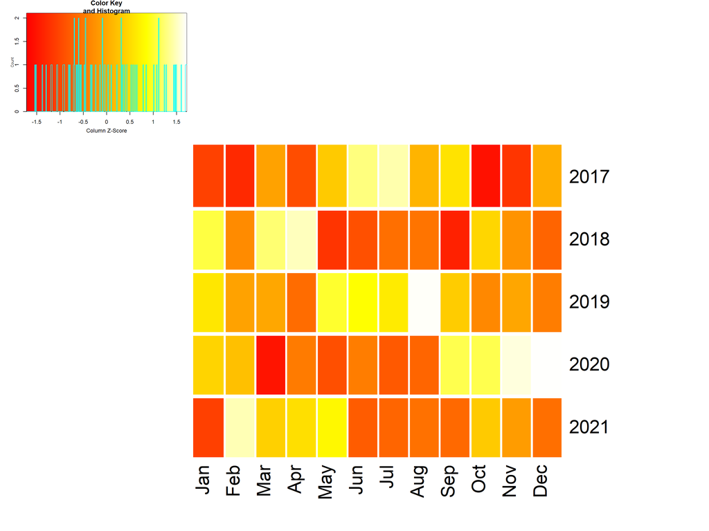

```r
heatmap.2(campus_gas_mat, Rowv=NA, Colv=NA, scale="column",
          col=heat.colors(256),margins=c(10,20),
          colsep=c(1:12),rowsep=(1:9), sepwidth=c(0.05,0.05),
          sepcolor="white",cexRow=3,cexCol=3,trace="none",
          dendrogram="none")
```

And we can also change the color scheme:

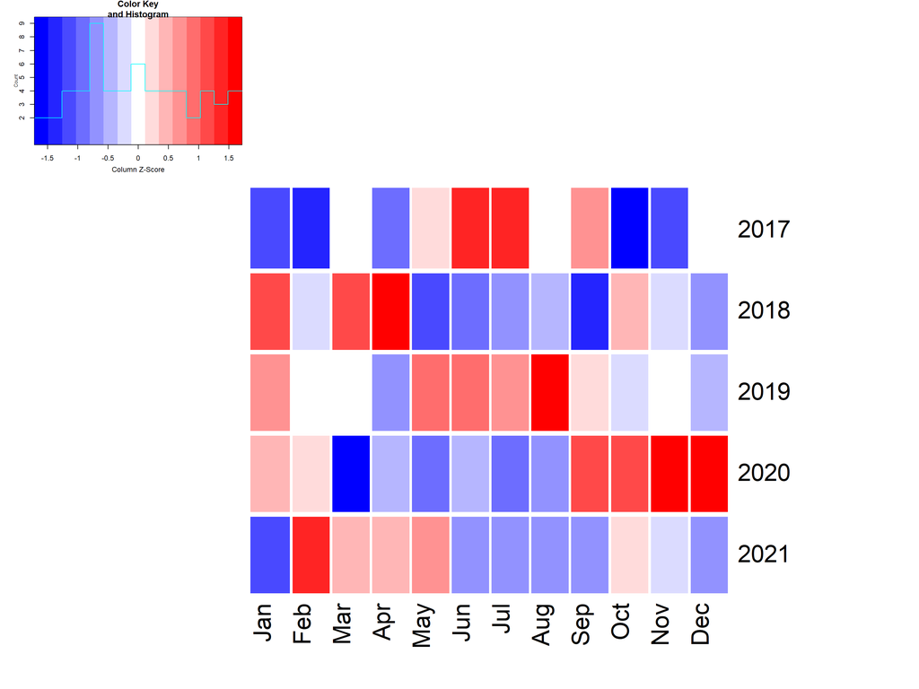

```r
heatmap.2(campus_gas_mat, Rowv=NA, Colv=NA, scale="column",
          col="bluered",margins=c(10,20),
          colsep=c(1:12),rowsep=(1:9), sepwidth=c(0.05,0.05),
          sepcolor="white",cexRow=3,cexCol=3,trace="none",
          dendrogram="none")
```

**Heat map with row clusters**

It can be tough to identify interesting patterns by visually comparing across rows and columns. Including *dendrograms* helps to identify interesting clusters.

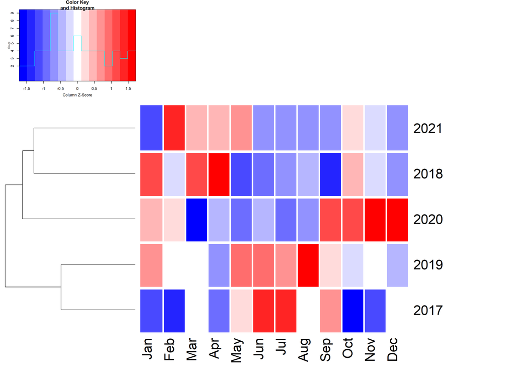

```r
heatmap.2(campus_gas_mat, Colv=NA, scale="column",
          col="bluered",margins=c(10,20),
          colsep=c(1:12),rowsep=(1:9), sepwidth=c(0.05,0.05),
          sepcolor="white",cexRow=3,cexCol=3,trace="none",
          dendrogram="row")
```

**Heat map with column clusters**

We can also construct a heat map which identifies interesting clusters of columns (variables).

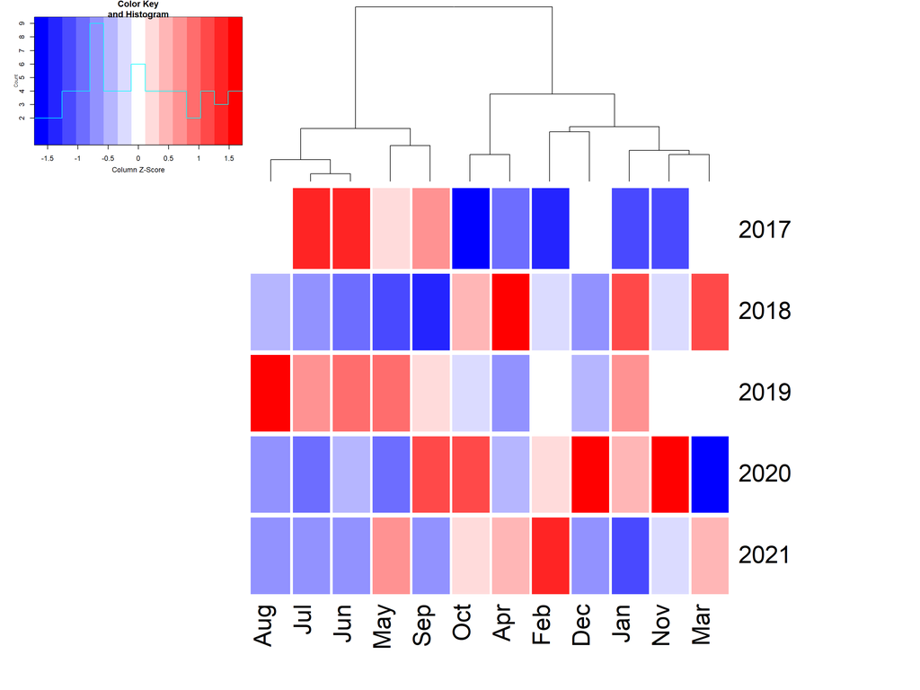

```r
heatmap.2(campus_gas_mat, Rowv=NA,  scale="column",
          col="bluered",margins=c(10,20),
          colsep=c(1:12),rowsep=(1:9), sepwidth=c(0.05,0.05),
          sepcolor="white",cexRow=3,cexCol=3,trace="none",
          dendrogram="column")
```

## 5.3 Other Options

- The package `heatmap3` makes heat maps in a similar way to the `heatmap.2` function above
- You can also look into [star plots](https://www.math.ucla.edu/~anderson/rw1001/library/base/html/stars.html) via the `stars` function

# 6 Explore

**Exercise 6.1 (Additional exploration)**

1. Write down one additional research question you think can be answered with this data.
2. Make a visualization to explore that question.

*Solution*.

1. How does West Hall consumption differ from East Hall?

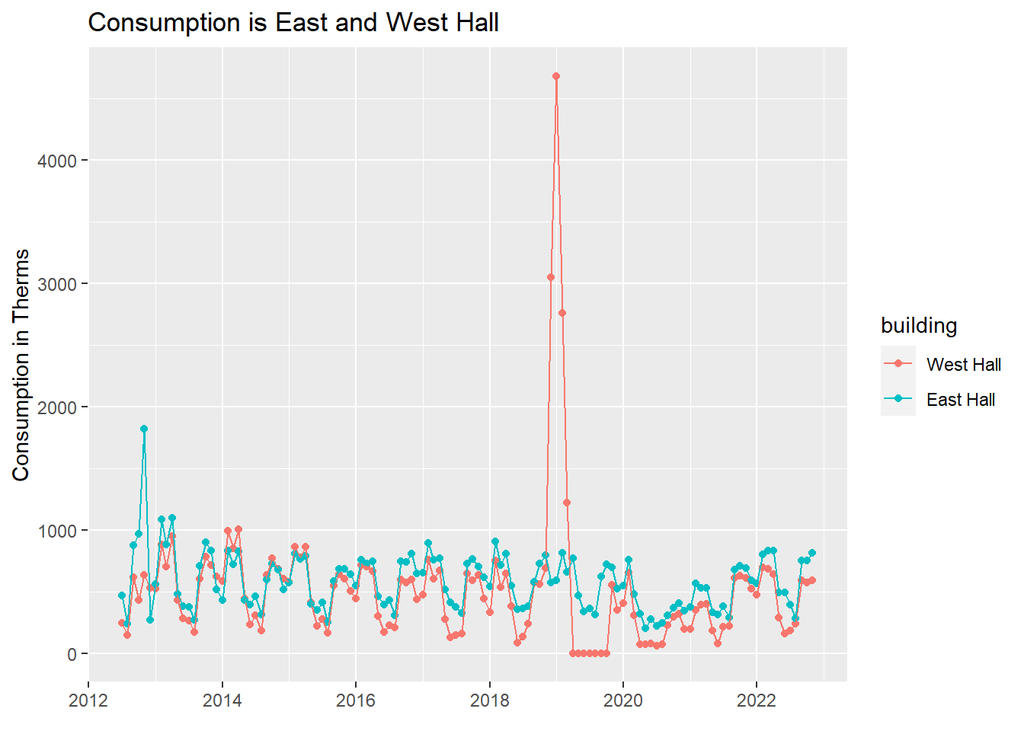

```r
ggplot(subset(gas_usage, building %in% c("West Hall", "East Hall")), aes(x=date, y=therms, color=building))+
  geom_point()+
  geom_line()+
  ggtitle("Consumption is East and West Hall")+
  labs(x=element_blank(), y="Consumption in Therms")
```